# Basic detection and categorisation of events

Robert Schlegel

Sorbonne Université

2023-07-24

*Know the rules well, so you can break them effectively.*  
–Dalai Lama

*Learn the rules like a pro, so you can break them like an artist.*  
–Pablo Picasso

We are interested in the why more than the how.

However, to evolve the why we need a deep understanding of the how.

But beware, if we focus on the how, we may get stuck in dogmatic thinking and forget the why.

How:

**Statistical decomposition of temperature time series**

Why:

**Reference point around which to investigate:**

- physical forces of extreme temperature
- bio/ecological impacts of extreme temperature
- socio/economic impacts of extreme temperature

## How - definition

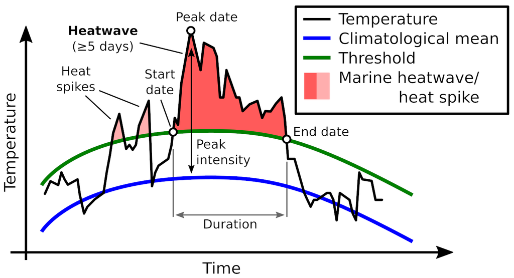

Oliver; [MHW International Working group](http://www.marineheatwaves.org/)

## How - categories

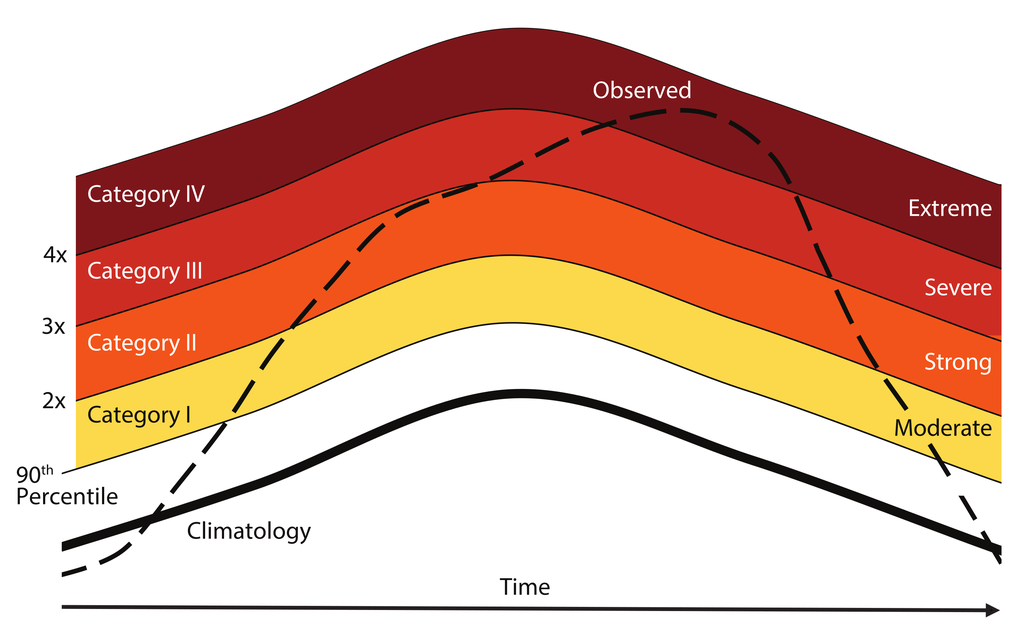

Hobday et al. (2018) *Categorizing and Naming Marine Heatwaves*

## Detecting extreme events

1. Pick a time series
2. Set the baseline period
3. Chose a threshold value
4. Detect consecutive days
5. Calculate metrics

## MHW demo

Scan me:

[figure not shown]

or [click](http://193.50.85.71:3838/demoMHW/) to activate MHW demo

## Language of choice

- R
- python
- MATLAB

[figure not shown]

https://robwschlegel.github.io/heatwaveR/index.html

**marineHeatWaves**  
https://github.com/ecjoliver/marineHeatWaves

**m_mhw**  
https://github.com/ZijieZhaoMMHW/m_mhw1.0

## Downloading data

- Manual link
- R
- Python
- MATLAB

NOAA GRIDDAP server  
https://coastwatch.pfeg.noaa.gov/erddap/griddap/ncdcOisst21Agg.html

See resources on [programme page](https://www.clivar.org/mhw-summer-school-draft-programme):  
https://www.clivar.org/mhw-summer-school-draft-programme

OR after the summer school:  
*Downloading and Preparing NOAA OISST Data*  
https://robwschlegel.github.io/heatwaveR/articles/OISST_preparation.html

See [Google colab](https://github.com/amandineschaeffer/Teaching_tutorials) from Amandine:  
https://github.com/amandineschaeffer/Teaching_tutorials

See resources on [programme page](https://www.clivar.org/mhw-summer-school-draft-programme):  
https://www.clivar.org/mhw-summer-school-draft-programme

## Why

[figure not shown]